# Module5Assignment(PartB)

```python
"""
Module 10 - Neural NLP System (improved)
Runs as a single Python file and renders plots inline with plt.show().

Recommended install:
    pip install torch transformers scikit-learn matplotlib numpy

Notebook usage:
    %matplotlib inline
    %run module10_nlp_system_improved.py
"""

import math
import random
import re
from collections import Counter, defaultdict
from dataclasses import dataclass

import numpy as np
import matplotlib.pyplot as plt

import torch
import torch.nn as nn
import torch.optim as optim
from torch.utils.data import Dataset, DataLoader

from sklearn.metrics import (
    accuracy_score,
    precision_recall_fscore_support,
    confusion_matrix,
    ConfusionMatrixDisplay,
)
from sklearn.model_selection import train_test_split
from sklearn.decomposition import PCA

from transformers import AutoTokenizer, AutoModelForSequenceClassification


# ============================================================
# GLOBAL SETTINGS
# ============================================================

SEED = 42
random.seed(SEED)
np.random.seed(SEED)
torch.manual_seed(SEED)

DEVICE = torch.device("cuda" if torch.cuda.is_available() else "cpu")

plt.rcParams["figure.figsize"] = (8, 5)
plt.rcParams["axes.grid"] = True

print(f"\nUsing device: {DEVICE}\n")


# ============================================================
# HELPERS
# ============================================================

def simple_tokenize(text: str):
    text = text.lower().strip()
    text = re.sub(r"[^a-z0-9\s']", "", text)
    return text.split()

def plot_curve(values, title, ylabel):
    plt.figure()
    plt.plot(range(1, len(values) + 1), values)
    plt.title(title)
    plt.xlabel("Epoch")
    plt.ylabel(ylabel)
    plt.show()

def compute_classification_metrics(y_true, y_pred):
    precision, recall, f1, _ = precision_recall_fscore_support(
        y_true, y_pred, average="binary", zero_division=0
    )
    acc = accuracy_score(y_true, y_pred)
    return {
        "accuracy": acc,
        "precision": precision,
        "recall": recall,
        "f1": f1,
    }


# ============================================================
# DATA GENERATION FOR PARTS 1-3
# ============================================================

def build_synthetic_corpus():
    sports_subjects = ["athlete", "runner", "player", "sprinter", "coach"]
    sports_verbs = ["trains", "runs", "practices", "sprints", "lifts"]
    sports_places = ["gym", "track", "field", "stadium"]
    sports_times = ["morning", "evening", "afternoon"]

    education_subjects = ["student", "teacher", "researcher", "learner", "tutor"]
    education_verbs = ["studies", "reads", "writes", "learns", "reviews"]
    education_places = ["library", "classroom", "lab", "campus"]
    education_times = ["morning", "night", "weekend"]

    arts_subjects = ["musician", "artist", "actor", "painter", "singer"]
    arts_verbs = ["plays", "rehearses", "creates", "paints", "performs"]
    arts_places = ["studio", "stage", "theater", "gallery"]
    arts_times = ["evening", "night", "weekend"]

    adjectives = ["dedicated", "focused", "talented", "disciplined", "creative"]
    frequency = ["every day", "every week", "after class", "before practice"]

    sentences = []
    labeled = []

    for _ in range(220):
        s = random.choice(sports_subjects)
        v = random.choice(sports_verbs)
        p = random.choice(sports_places)
        t = random.choice(sports_times)
        a = random.choice(adjectives)
        f = random.choice(frequency)
        variants = [
            f"the {a} {s} {v} in the {p} every {t}",
            f"the {s} {v} in the {p} {f}",
            f"the {s} {v} with the coach at the {p}",
            f"the {s} {v} hard in the {p} during the {t}",
        ]
        text = random.choice(variants)
        sentences.append(text)
        labeled.append((text, "sports"))

    for _ in range(220):
        s = random.choice(education_subjects)
        v = random.choice(education_verbs)
        p = random.choice(education_places)
        t = random.choice(education_times)
        a = random.choice(adjectives)
        f = random.choice(frequency)
        variants = [
            f"the {a} {s} {v} in the {p} every {t}",
            f"the {s} {v} in the {p} {f}",
            f"the {s} {v} notes with the teacher in the {p}",
            f"the {s} {v} carefully in the {p} during the {t}",
        ]
        text = random.choice(variants)
        sentences.append(text)
        labeled.append((text, "education"))

    for _ in range(220):
        s = random.choice(arts_subjects)
        v = random.choice(arts_verbs)
        p = random.choice(arts_places)
        t = random.choice(arts_times)
        a = random.choice(adjectives)
        f = random.choice(frequency)
        variants = [
            f"the {a} {s} {v} in the {p} every {t}",
            f"the {s} {v} in the {p} {f}",
            f"the {s} {v} with the director at the {p}",
            f"the {s} {v} creatively in the {p} during the {t}",
        ]
        text = random.choice(variants)
        sentences.append(text)
        labeled.append((text, "arts"))

    random.shuffle(sentences)
    random.shuffle(labeled)
    return sentences, labeled

sentences, labeled_sentences = build_synthetic_corpus()


# ============================================================
# PART 1 - WORD REPRESENTATIONS (CBOW + SIMILARITY + PCA)
# ============================================================

print("=" * 70)
print("PART 1 - WORD REPRESENTATIONS WITH EMBEDDINGS")
print("=" * 70)

tokenized_sentences = [simple_tokenize(s) for s in sentences]
all_words = [w for sent in tokenized_sentences for w in sent]
vocab = sorted(set(all_words))
word_to_ix = {w: i for i, w in enumerate(vocab)}
ix_to_word = {i: w for w, i in word_to_ix.items()}
vocab_size = len(vocab)

context_size = 2
training_pairs = []

for sent in tokenized_sentences:
    if len(sent) < 2 * context_size + 1:
        continue
    for i in range(context_size, len(sent) - context_size):
        context = sent[i - context_size:i] + sent[i + 1:i + context_size + 1]
        target = sent[i]
        training_pairs.append((context, target))
```

```python
train_pairs, val_pairs = train_test_split(training_pairs, test_size=0.2, random_state=SEED)

class CBOW(nn.Module):
    def __init__(self, vocab_size, embedding_dim):
        super().__init__()
        self.embeddings = nn.Embedding(vocab_size, embedding_dim)
        self.linear1 = nn.Linear(embedding_dim, 64)
        self.relu = nn.ReLU()
        self.linear2 = nn.Linear(64, vocab_size)

    def forward(self, inputs):
        embeds = self.embeddings(inputs)
        pooled = embeds.mean(dim=0).view(1, -1)
        x = self.linear1(pooled)
        x = self.relu(x)
        x = self.linear2(x)
        return x

def evaluate_cbow(model, pairs):
    model.eval()
    loss_fn = nn.CrossEntropyLoss()
    total = 0.0
    with torch.no_grad():
        for context, target in pairs:
            context_idxs = torch.tensor([word_to_ix[w] for w in context], dtype=torch.long).to(DEVICE)
            target_idx = torch.tensor([word_to_ix[target]], dtype=torch.long).to(DEVICE)
            logits = model(context_idxs)
            loss = loss_fn(logits, target_idx)
            total += loss.item()
    return total / max(1, len(pairs))

embedding_dim = 32
cbow_model = CBOW(vocab_size, embedding_dim).to(DEVICE)
cbow_loss_fn = nn.CrossEntropyLoss()
cbow_optimizer = optim.Adam(cbow_model.parameters(), lr=0.005)

cbow_train_losses = []
cbow_val_losses = []

for epoch in range(30):
    cbow_model.train()
    total_loss = 0.0
    random.shuffle(train_pairs)

    for context, target in train_pairs:
        context_idxs = torch.tensor([word_to_ix[w] for w in context], dtype=torch.long).to(DEVICE)
        target_idx = torch.tensor([word_to_ix[target]], dtype=torch.long).to(DEVICE)

        cbow_optimizer.zero_grad()
        logits = cbow_model(context_idxs)
        loss = cbow_loss_fn(logits, target_idx)
        loss.backward()
        nn.utils.clip_grad_norm_(cbow_model.parameters(), 1.0)
        cbow_optimizer.step()
        total_loss += loss.item()

    avg_train = total_loss / len(train_pairs)
    avg_val = evaluate_cbow(cbow_model, val_pairs)
    cbow_train_losses.append(avg_train)
    cbow_val_losses.append(avg_val)

    if (epoch + 1) % 5 == 0:
        print(f"Epoch {epoch + 1:2d} | CBOW Train Loss = {avg_train:.4f} | Val Loss = {avg_val:.4f}")

def cosine_similarity(vec1, vec2):
    return torch.dot(vec1, vec2) / (torch.norm(vec1) * torch.norm(vec2) + 1e-8)

def most_similar(model, word, top_k=5):
    model.eval()
    if word not in word_to_ix:
        return []
    with torch.no_grad():
        emb = model.embeddings.weight.data
        idx = word_to_ix[word]
        vec = emb[idx]
        sims = []
        for w, j in word_to_ix.items():
            if w == word:
                continue
            sims.append((w, cosine_similarity(vec, emb[j]).item()))
        sims.sort(key=lambda x: x[1], reverse=True)
        return sims[:top_k]

print("\nEmbedding similarity results:")
similarity_results = {}
for probe in ["athlete", "student", "musician", "library", "studio", "track"]:
    sims = most_similar(cbow_model, probe, top_k=5)
    similarity_results[probe] = sims
    print(f"\nMost similar to '{probe}':")
    for neighbor, score in sims:
        print(f"  {neighbor:12s} -> {score:.4f}")

# Plot training and validation loss
plt.figure()
plt.plot(range(1, len(cbow_train_losses) + 1), cbow_train_losses, label="Train")
plt.plot(range(1, len(cbow_val_losses) + 1), cbow_val_losses, label="Validation")
plt.title("CBOW Training vs Validation Loss")
plt.xlabel("Epoch")
plt.ylabel("Loss")
plt.legend()
plt.show()

# Similarity plot for one example word
example_word = "athlete"
labels = [w for w, _ in similarity_results[example_word]]
scores = [s for _, s in similarity_results[example_word]]
plt.figure()
plt.bar(labels, scores)
plt.title(f"Top Similar Words to '{example_word}'")
plt.xlabel("Word")
plt.ylabel("Cosine Similarity")
plt.xticks(rotation=30)
plt.show()

# PCA embedding plot
cbow_model.eval()
with torch.no_grad():
    embedding_matrix = cbow_model.embeddings.weight.detach().cpu().numpy()

probe_words = ["athlete", "runner", "player", "student", "teacher", "researcher", "musician", "artist", "actor",
               "gym", "track", "library", "classroom", "studio", "stage"]
probe_indices = [word_to_ix[w] for w in probe_words]
probe_vectors = embedding_matrix[probe_indices]
pca = PCA(n_components=2, random_state=SEED)
coords = pca.fit_transform(probe_vectors)

plt.figure(figsize=(9, 6))
for (x, y), word in zip(coords, probe_words):
    plt.scatter(x, y)
    plt.text(x + 0.02, y + 0.02, word, fontsize=9)
plt.title("PCA Projection of Selected Word Embeddings")
plt.xlabel("PC1")
plt.ylabel("PC2")
plt.show()


# ============================================================
# PART 2 - SEQUENCE MODELING (LSTM NEXT-WORD PREDICTION)
# ============================================================

print("\n" + "=" * 70)
print("PART 2 - SEQUENCE MODELING WITH LSTM")
print("=" * 70)

sequence_sentences = sentences[:450]
tokenized_seq = [simple_tokenize(s) for s in sequence_sentences]

seq_vocab = sorted(set(word for sent in tokenized_seq for word in sent))
seq_word_to_ix = {w: i + 1 for i, w in enumerate(seq_vocab)}  # 0 reserved for padding
seq_ix_to_word = {i: w for w, i in seq_word_to_ix.items()}
seq_vocab_size = len(seq_word_to_ix) + 1

X_seq = []
y_seq = []

for sent in tokenized_seq:
    for i in range(1, len(sent)):
        prefix = sent[:i]
        target = sent[i]
        X_seq.append(prefix)
        y_seq.append(target)

max_len_seq = max(len(x) for x in X_seq)

def encode_prefix(seq, mapping, max_len):
    ids = [mapping[w] for w in seq]
    ids += [0] * (max_len - len(ids))
    return ids

X_seq_enc = np.array([encode_prefix(x, seq_word_to_ix, max_len_seq) for x in X_seq], dtype=np.int64)
y_seq_enc = np.array([seq_word_to_ix[y] for y in y_seq], dtype=np.int64)

X_train, X_val, y_train, y_val = train_test_split(
    X_seq_enc, y_seq_enc, test_size=0.2, random_state=SEED
)

X_train_t = torch.tensor(X_train, dtype=torch.long).to(DEVICE)
X_val_t = torch.tensor(X_val, dtype=torch.long).to(DEVICE)
y_train_t = torch.tensor(y_train, dtype=torch.long).to(DEVICE)
y_val_t = torch.tensor(y_val, dtype=torch.long).to(DEVICE)
```

```python
class NextWordLSTM(nn.Module):
    def __init__(self, vocab_size, emb_dim=48, hidden_dim=96):
        super().__init__()
        self.embedding = nn.Embedding(vocab_size, emb_dim, padding_idx=0)
        self.lstm = nn.LSTM(emb_dim, hidden_dim, batch_first=True)
        self.dropout = nn.Dropout(0.15)
        self.fc = nn.Linear(hidden_dim, vocab_size)

    def forward(self, x):
        emb = self.embedding(x)
        _, (hidden, _) = self.lstm(emb)
        last_hidden = self.dropout(hidden[-1])
        logits = self.fc(last_hidden)
        return logits

def top_k_accuracy(logits, targets, k=3):
    topk = torch.topk(logits, k=k, dim=1).indices
    correct = (topk == targets.unsqueeze(1)).any(dim=1).float().mean().item()
    return correct

lstm_model = NextWordLSTM(seq_vocab_size).to(DEVICE)
lstm_loss_fn = nn.CrossEntropyLoss()
lstm_optimizer = optim.Adam(lstm_model.parameters(), lr=0.003)

lstm_train_losses, lstm_val_losses = [], []
lstm_train_accs, lstm_val_accs = [], []
lstm_train_top3, lstm_val_top3 = [], []

for epoch in range(20):
    lstm_model.train()
    lstm_optimizer.zero_grad()
    train_logits = lstm_model(X_train_t)
    train_loss = lstm_loss_fn(train_logits, y_train_t)
    train_loss.backward()
    nn.utils.clip_grad_norm_(lstm_model.parameters(), 1.0)
    lstm_optimizer.step()

    lstm_model.eval()
    with torch.no_grad():
        val_logits = lstm_model(X_val_t)
        val_loss = lstm_loss_fn(val_logits, y_val_t)

        train_preds = torch.argmax(train_logits, dim=1)
        val_preds = torch.argmax(val_logits, dim=1)

        train_acc = (train_preds == y_train_t).float().mean().item()
        val_acc = (val_preds == y_val_t).float().mean().item()

        train_top3 = top_k_accuracy(train_logits, y_train_t, 3)
        val_top3 = top_k_accuracy(val_logits, y_val_t, 3)

    lstm_train_losses.append(train_loss.item())
    lstm_val_losses.append(val_loss.item())
    lstm_train_accs.append(train_acc)
    lstm_val_accs.append(val_acc)
    lstm_train_top3.append(train_top3)
    lstm_val_top3.append(val_top3)

    if (epoch + 1) % 5 == 0:
        print(
            f"Epoch {epoch + 1:2d} | "
            f"Train Loss = {train_loss.item():.4f} | Val Loss = {val_loss.item():.4f} | "
            f"Train Acc = {train_acc:.4f} | Val Acc = {val_acc:.4f} | "
            f"Val Top-3 = {val_top3:.4f}"
        )

def predict_next_word(prefix, top_k=3):
    lstm_model.eval()
    tokens = simple_tokenize(prefix)
    encoded = encode_prefix(tokens, seq_word_to_ix, max_len_seq)
    x = torch.tensor([encoded], dtype=torch.long).to(DEVICE)
    with torch.no_grad():
        logits = lstm_model(x)
        probs = torch.softmax(logits, dim=1)
        topk = torch.topk(probs, k=top_k, dim=1)
    results = []
    for idx, prob in zip(topk.indices[0].cpu().tolist(), topk.values[0].cpu().tolist()):
        results.append((seq_ix_to_word.get(idx, "[UNK]"), prob))
    return results

print("\nNext-word prediction examples:")
for prompt in [
    "the athlete",
    "the athlete trains in the",
    "the student studies in the",
    "the musician performs in the",
    "the researcher reads in the",
]:
    preds = predict_next_word(prompt, top_k=3)
    print(f"\nInput: '{prompt}'")
    for word, prob in preds:
        print(f"  {word:12s} prob={prob:.4f}")

plt.figure()
plt.plot(range(1, len(lstm_train_losses) + 1), lstm_train_losses, label="Train")
plt.plot(range(1, len(lstm_val_losses) + 1), lstm_val_losses, label="Validation")
plt.title("LSTM Training vs Validation Loss")
plt.xlabel("Epoch")
plt.ylabel("Loss")
plt.legend()
plt.show()

plt.figure()
plt.plot(range(1, len(lstm_train_accs) + 1), lstm_train_accs, label="Train Acc")
plt.plot(range(1, len(lstm_val_accs) + 1), lstm_val_accs, label="Validation Acc")
plt.plot(range(1, len(lstm_val_top3) + 1), lstm_val_top3, label="Validation Top-3 Acc")
plt.title("LSTM Accuracy Curves")
plt.xlabel("Epoch")
plt.ylabel("Accuracy")
plt.legend()
plt.show()


# ============================================================
# PART 3 - ATTENTION CLASSIFIER WITH TRAIN/VAL/TEST
# ============================================================

print("\n" + "=" * 70)
print("PART 3 - ATTENTION-BASED TEXT CLASSIFICATION")
print("=" * 70)

label_map = {"sports": 0, "education": 1, "arts": 2}
inv_label_map = {v: k for k, v in label_map.items()}

texts = [simple_tokenize(t) for t, label in labeled_sentences]
labels = [label_map[label] for _, label in labeled_sentences]

att_vocab = sorted(set(w for sent in texts for w in sent))
att_word_to_ix = {w: i + 1 for i, w in enumerate(att_vocab)}  # 0 = padding
att_vocab_size = len(att_word_to_ix) + 1
max_len_att = max(len(s) for s in texts)

def encode_text(words):
    ids = [att_word_to_ix[w] for w in words]
    ids += [0] * (max_len_att - len(ids))
    return ids

X_att = np.array([encode_text(t) for t in texts], dtype=np.int64)
y_att = np.array(labels, dtype=np.int64)

X_temp, X_test, y_temp, y_test = train_test_split(
    X_att, y_att, test_size=0.15, random_state=SEED, stratify=y_att
)
X_train, X_val, y_train, y_val = train_test_split(
    X_temp, y_temp, test_size=0.15, random_state=SEED, stratify=y_temp
)

X_train_t = torch.tensor(X_train, dtype=torch.long).to(DEVICE)
X_val_t = torch.tensor(X_val, dtype=torch.long).to(DEVICE)
X_test_t = torch.tensor(X_test, dtype=torch.long).to(DEVICE)

y_train_t = torch.tensor(y_train, dtype=torch.long).to(DEVICE)
y_val_t = torch.tensor(y_val, dtype=torch.long).to(DEVICE)
y_test_t = torch.tensor(y_test, dtype=torch.long).to(DEVICE)

class AttentionClassifier(nn.Module):
    def __init__(self, vocab_size, emb_dim=48, hidden_dim=64, num_classes=3):
        super().__init__()
        self.embedding = nn.Embedding(vocab_size, emb_dim, padding_idx=0)
        self.lstm = nn.LSTM(emb_dim, hidden_dim, batch_first=True, bidirectional=True)
        self.attn = nn.Linear(hidden_dim * 2, 1)
        self.dropout = nn.Dropout(0.2)
        self.fc = nn.Linear(hidden_dim * 2, num_classes)

    def forward(self, x):
        emb = self.embedding(x)
        outputs, _ = self.lstm(emb)
        attn_scores = self.attn(outputs).squeeze(-1)
        attn_weights = torch.softmax(attn_scores, dim=1)
        context = torch.sum(outputs * attn_weights.unsqueeze(-1), dim=1)
        logits = self.fc(self.dropout(context))
        return logits, attn_weights
```

```python
att_model = AttentionClassifier(att_vocab_size).to(DEVICE)
att_loss_fn = nn.CrossEntropyLoss()
att_optimizer = optim.Adam(att_model.parameters(), lr=0.003)

att_train_losses, att_val_losses = [], []
att_train_accs, att_val_accs = [], []

for epoch in range(18):
    att_model.train()
    att_optimizer.zero_grad()
    train_logits, _ = att_model(X_train_t)
    train_loss = att_loss_fn(train_logits, y_train_t)
    train_loss.backward()
    nn.utils.clip_grad_norm_(att_model.parameters(), 1.0)
    att_optimizer.step()

    att_model.eval()
    with torch.no_grad():
        val_logits, _ = att_model(X_val_t)
        val_loss = att_loss_fn(val_logits, y_val_t)

        train_preds = torch.argmax(train_logits, dim=1)
        val_preds = torch.argmax(val_logits, dim=1)

        train_acc = (train_preds == y_train_t).float().mean().item()
        val_acc = (val_preds == y_val_t).float().mean().item()

    att_train_losses.append(train_loss.item())
    att_val_losses.append(val_loss.item())
    att_train_accs.append(train_acc)
    att_val_accs.append(val_acc)

    if (epoch + 1) % 3 == 0:
        print(
            f"Epoch {epoch + 1:2d} | Train Loss = {train_loss.item():.4f} | Val Loss = {val_loss.item():.4f} | "
            f"Train Acc = {train_acc:.4f} | Val Acc = {val_acc:.4f}"
        )

att_model.eval()
with torch.no_grad():
    test_logits, _ = att_model(X_test_t)
    test_preds = torch.argmax(test_logits, dim=1).cpu().numpy()

test_acc = accuracy_score(y_test, test_preds)
print(f"\nAttention classifier test accuracy: {test_acc:.4f}")

plt.figure()
plt.plot(range(1, len(att_train_losses) + 1), att_train_losses, label="Train")
plt.plot(range(1, len(att_val_losses) + 1), att_val_losses, label="Validation")
plt.title("Attention Classifier Training vs Validation Loss")
plt.xlabel("Epoch")
plt.ylabel("Loss")
plt.legend()
plt.show()

plt.figure()
plt.plot(range(1, len(att_train_accs) + 1), att_train_accs, label="Train")
plt.plot(range(1, len(att_val_accs) + 1), att_val_accs, label="Validation")
plt.title("Attention Classifier Training vs Validation Accuracy")
plt.xlabel("Epoch")
plt.ylabel("Accuracy")
plt.legend()
plt.show()

cm = confusion_matrix(y_test, test_preds)
disp = ConfusionMatrixDisplay(confusion_matrix=cm, display_labels=["sports", "education", "arts"])
disp.plot()
plt.title("Attention Classifier Confusion Matrix")
plt.show()

def show_attention(sentence):
    tokens = simple_tokenize(sentence)
    encoded = encode_text(tokens)
    x = torch.tensor([encoded], dtype=torch.long).to(DEVICE)

    att_model.eval()
    with torch.no_grad():
        logits, weights = att_model(x)
        pred = torch.argmax(logits, dim=1).item()

    weights = weights[0][:len(tokens)].detach().cpu().numpy()

    print(f"\nSentence: {sentence}")
    print(f"Predicted class: {inv_label_map[pred]}")
    print("Attention weights:")
    for token, weight in zip(tokens, weights):
        print(f"  {token:12s} -> {weight:.4f}")

    plt.figure()
    plt.bar(tokens, weights)
    plt.title(f"Attention Weights: {sentence}")
    plt.xlabel("Token")
    plt.ylabel("Attention Weight")
    plt.xticks(rotation=30)
    plt.show()

show_attention("the dedicated athlete trains in the gym every morning")
show_attention("the focused student studies in the library every night")
show_attention("the creative musician performs in the studio every evening")


# ============================================================
# PART 4 - TRANSFER LEARNING WITH DISTILBERT
# Custom PyTorch loop, no datasets/trainer/accelerate needed
# ============================================================

print("\n" + "=" * 70)
print("PART 4 - TRANSFER LEARNING WITH DISTILBERT")
print("=" * 70)

positive_texts = [
    "I loved this movie and the acting was excellent",
    "The film was wonderful and very moving",
    "An amazing story with strong performances",
    "I really enjoyed the movie from start to finish",
    "This was a great film with a satisfying ending",
    "The performance was brilliant and emotional",
    "I liked the characters and the story a lot",
    "The movie was fun, warm, and entertaining",
    "An excellent film with beautiful direction",
    "The acting and soundtrack were fantastic",
    "I had a great time watching this movie",
    "The film was engaging and well written",
    "A smart and enjoyable story",
    "This movie was charming and heartfelt",
    "The cast did a wonderful job",
    "The plot was strong and the ending was great",
    "A very good movie that I would recommend",
    "This film was impressive and emotionally rich",
    "I was pleasantly surprised by how good it was",
    "The movie was thoughtful, moving, and strong",
    "I loved the visuals and the performances",
    "A creative and satisfying film",
    "The story was meaningful and beautifully told",
    "It was funny, touching, and very well made",
    "I enjoyed this film much more than I expected",
    "The script was sharp and the acting was excellent",
    "This was a powerful and inspiring movie",
    "A delightful film with excellent pacing",
    "The movie felt fresh, smart, and enjoyable",
    "I would happily watch this film again",
    "The experience was positive and memorable",
    "This was one of the better films I have seen lately",
    "The performances were strong and convincing",
    "The movie had heart and a strong message",
    "I genuinely liked this movie a lot",
    "The film was polished and very entertaining",
]

negative_texts = [
    "I hated this movie and the acting was awful",
    "The film was boring and badly written",
    "A disappointing story with weak performances",
    "I did not enjoy the movie at all",
    "This was a terrible film with a weak ending",
    "The performance was flat and unconvincing",
    "I disliked the characters and the story",
    "The movie was dull, slow, and forgettable",
    "A bad film with poor direction",
    "The acting and soundtrack were disappointing",
    "I wasted my time watching this movie",
    "The film was messy and poorly written",
    "A weak and frustrating story",
    "This movie was lifeless and predictable",
    "The cast did a poor job",
    "The plot was weak and the ending was bad",
    "A very bad movie that I would not recommend",
    "This film was underwhelming and emotionally empty",
    "I was surprised by how bad it was",
    "The movie was clumsy, slow, and weak",
    "I hated the visuals and the performances",
    "A confused and unsatisfying film",
    "The story was shallow and badly told",
    "It was annoying, flat, and poorly made",
    "I regret watching this film",
    "The script was weak and the acting was poor",
    "This was a frustrating and uninspired movie",
    "A forgettable film with terrible pacing",
    "The movie felt tired, obvious, and dull",
    "I would not watch this film again",
    "The experience was negative and disappointing",
    "This was one of the weaker films I have seen lately",
    "The performances were weak and unbelievable",
    "The movie had no heart and no clear message",
    "I genuinely disliked this movie a lot",
    "The film was sloppy and not entertaining",
]
```

```python
all_texts = positive_texts + negative_texts
all_labels = [1] * len(positive_texts) + [0] * len(negative_texts)

# split into train/val/test
X_temp, X_test, y_temp, y_test = train_test_split(
    all_texts, all_labels, test_size=0.2, random_state=SEED, stratify=all_labels
)
X_train, X_val, y_train, y_val = train_test_split(
    X_temp, y_temp, test_size=0.2, random_state=SEED, stratify=y_temp
)

class TextClassificationDataset(Dataset):
    def __init__(self, texts, labels, tokenizer, max_length=64):
        self.encodings = tokenizer(
            texts,
            truncation=True,
            padding=True,
            max_length=max_length,
            return_tensors="pt",
        )
        self.labels = torch.tensor(labels, dtype=torch.long)

    def __len__(self):
        return len(self.labels)

    def __getitem__(self, idx):
        item = {key: val[idx] for key, val in self.encodings.items()}
        item["labels"] = self.labels[idx]
        return item

print("Loading tokenizer and pretrained model...")
model_name = "distilbert-base-uncased"
tokenizer = AutoTokenizer.from_pretrained(model_name)
bert_model = AutoModelForSequenceClassification.from_pretrained(model_name, num_labels=2).to(DEVICE)

# freeze lower layers for speed/stability on laptop; unfreeze top transformer block + classifier head
for param in bert_model.distilbert.parameters():
    param.requires_grad = False

for param in bert_model.distilbert.transformer.layer[-1].parameters():
    param.requires_grad = True

for param in bert_model.pre_classifier.parameters():
    param.requires_grad = True
for param in bert_model.classifier.parameters():
    param.requires_grad = True

train_ds = TextClassificationDataset(X_train, y_train, tokenizer)
val_ds = TextClassificationDataset(X_val, y_val, tokenizer)
test_ds = TextClassificationDataset(X_test, y_test, tokenizer)

train_loader = DataLoader(train_ds, batch_size=8, shuffle=True)
val_loader = DataLoader(val_ds, batch_size=8, shuffle=False)
test_loader = DataLoader(test_ds, batch_size=8, shuffle=False)

bert_optimizer = optim.AdamW(filter(lambda p: p.requires_grad, bert_model.parameters()), lr=2e-5)

def evaluate_bert(model, loader):
    model.eval()
    losses = []
    preds = []
    trues = []
    with torch.no_grad():
        for batch in loader:
            labels = batch["labels"].cpu().numpy().tolist()
            batch = {k: v.to(DEVICE) for k, v in batch.items()}
            outputs = model(**batch)
            losses.append(outputs.loss.item())
            batch_preds = torch.argmax(outputs.logits, dim=1).cpu().numpy().tolist()
            preds.extend(batch_preds)
            trues.extend(labels)

    metrics = compute_classification_metrics(trues, preds)
    metrics["loss"] = float(np.mean(losses)) if losses else float("nan")
    return metrics, trues, preds

majority_baseline = max(Counter(y_train).values()) / len(y_train)

def keyword_baseline_predict(text):
    positive_keywords = {"love", "loved", "great", "excellent", "wonderful", "amazing", "enjoyed", "good", "satisfying", "fun"}
    negative_keywords = {"hate", "hated", "bad", "awful", "boring", "terrible", "weak", "poor", "dull", "disappointing"}
    toks = set(simple_tokenize(text))
    pos_hits = len(toks & positive_keywords)
    neg_hits = len(toks & negative_keywords)
    return 1 if pos_hits >= neg_hits else 0

keyword_preds = [keyword_baseline_predict(t) for t in X_test]
keyword_metrics = compute_classification_metrics(y_test, keyword_preds)

print(f"Majority baseline accuracy on training distribution: {majority_baseline:.4f}")
print(
    f"Keyword baseline test metrics -> "
    f"accuracy={keyword_metrics['accuracy']:.4f}, "
    f"precision={keyword_metrics['precision']:.4f}, "
    f"recall={keyword_metrics['recall']:.4f}, "
    f"f1={keyword_metrics['f1']:.4f}"
)

bert_train_losses = []
bert_val_losses = []
bert_val_accs = []

best_state = None
best_val_f1 = -1.0

for epoch in range(3):
    bert_model.train()
    running_loss = 0.0

    for batch in train_loader:
        batch = {k: v.to(DEVICE) for k, v in batch.items()}
        bert_optimizer.zero_grad()
        outputs = bert_model(**batch)
        loss = outputs.loss
        loss.backward()
        nn.utils.clip_grad_norm_(filter(lambda p: p.requires_grad, bert_model.parameters()), 1.0)
        bert_optimizer.step()
        running_loss += loss.item()

    train_loss = running_loss / len(train_loader)
    val_metrics, _, _ = evaluate_bert(bert_model, val_loader)

    bert_train_losses.append(train_loss)
    bert_val_losses.append(val_metrics["loss"])
    bert_val_accs.append(val_metrics["accuracy"])

    print(
        f"Epoch {epoch + 1:2d} | "
        f"Train Loss = {train_loss:.4f} | Val Loss = {val_metrics['loss']:.4f} | "
        f"Val Acc = {val_metrics['accuracy']:.4f} | Val F1 = {val_metrics['f1']:.4f}"
    )

    if val_metrics["f1"] > best_val_f1:
        best_val_f1 = val_metrics["f1"]
        best_state = {k: v.cpu().clone() for k, v in bert_model.state_dict().items()}

if best_state is not None:
    bert_model.load_state_dict(best_state)

test_metrics, test_true, test_preds = evaluate_bert(bert_model, test_loader)

print("\nDistilBERT evaluation results:")
for k in ["accuracy", "precision", "recall", "f1", "loss"]:
    print(f"{k}: {test_metrics[k]:.4f}")

def predict_sentiment(text):
    bert_model.eval()
    encoded = tokenizer(text, truncation=True, padding=True, max_length=64, return_tensors="pt")
    encoded = {k: v.to(DEVICE) for k, v in encoded.items()}
    with torch.no_grad():
        outputs = bert_model(**encoded)
        pred = torch.argmax(outputs.logits, dim=1).item()
        prob = torch.softmax(outputs.logits, dim=1)[0, pred].item()
    return ("positive" if pred == 1 else "negative"), prob

examples = [
    "I absolutely loved the movie and the performances were excellent",
    "The film was a waste of time and painfully boring",
    "The story was strong, emotional, and beautifully acted",
    "I do not recommend this movie because it was dull and weak",
]
```

```
Using device: cpu

======================================================================
PART 1 - WORD REPRESENTATIONS WITH EMBEDDINGS
======================================================================
Epoch  5 | CBOW Train Loss = 0.8477 | Val Loss = 0.9291
Epoch 10 | CBOW Train Loss = 0.8110 | Val Loss = 1.1523
Epoch 15 | CBOW Train Loss = 0.8394 | Val Loss = 1.1859
Epoch 20 | CBOW Train Loss = 0.8154 | Val Loss = 1.3045
Epoch 25 | CBOW Train Loss = 0.8298 | Val Loss = 1.3766
Epoch 30 | CBOW Train Loss = 0.8069 | Val Loss = 1.6411

Embedding similarity results:

Most similar to 'athlete':
  sprinter     -> 0.5671
  coach        -> 0.5521
  during       -> 0.3675
  runs         -> 0.3516
  lifts        -> 0.3490

Most similar to 'student':
  gallery      -> 0.5383
  track        -> 0.5043
  theater      -> 0.5034
  stadium      -> 0.4381
  classroom    -> 0.4247

Most similar to 'musician':
  artist       -> 0.4582
  painter      -> 0.4325
  singer       -> 0.3283
  actor        -> 0.2556
  creative     -> 0.1761

Most similar to 'library':
  lab          -> 0.7364
  theater      -> 0.7184
  classroom    -> 0.7099
  gallery      -> 0.7025
  campus       -> 0.6954

Most similar to 'studio':
  classroom    -> 0.7776
  theater      -> 0.7655
  field        -> 0.7539
  track        -> 0.7314
  stadium      -> 0.6860

Most similar to 'track':
  field        -> 0.7993
  theater      -> 0.7774
  stadium      -> 0.7672
  gym          -> 0.7593
  studio       -> 0.7314
```

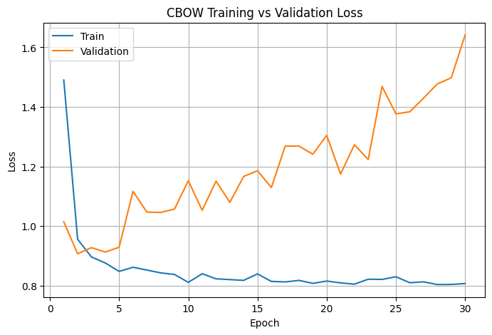

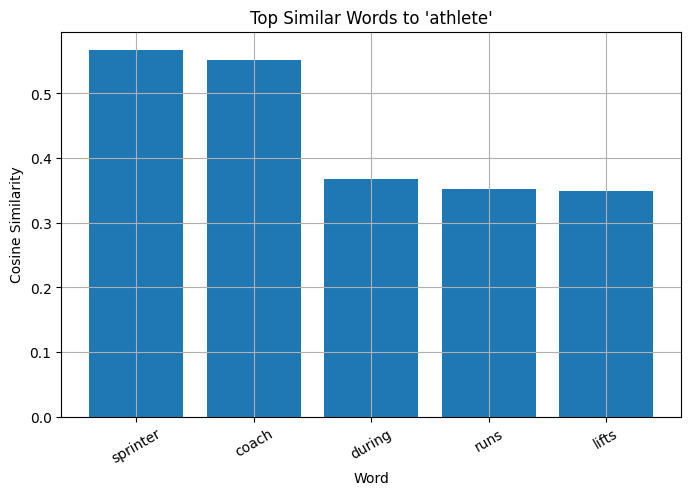

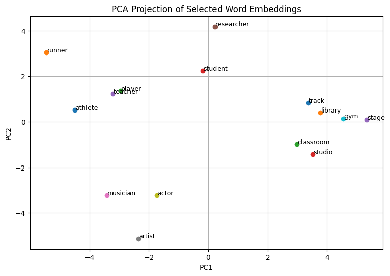

```
======================================================================
PART 2 - SEQUENCE MODELING WITH LSTM
======================================================================
Epoch  5 | Train Loss = 4.0928 | Val Loss = 4.0101 | Train Acc = 0.1894 | Val Acc = 0.2096 | Val Top-3 = 0.3288
Epoch 10 | Train Loss = 3.7413 | Val Loss = 3.6646 | Train Acc = 0.1795 | Val Acc = 0.2041 | Val Top-3 = 0.3548
Epoch 15 | Train Loss = 3.5331 | Val Loss = 3.4838 | Train Acc = 0.1826 | Val Acc = 0.2110 | Val Top-3 = 0.3877
Epoch 20 | Train Loss = 3.2841 | Val Loss = 3.1867 | Train Acc = 0.1939 | Val Acc = 0.2205 | Val Top-3 = 0.4096

Next-word prediction examples:

Input: 'the athlete'
  the          prob=0.1581
  in           prob=0.1194
  with         prob=0.0366

Input: 'the athlete trains in the'
  the          prob=0.2351
  every        prob=0.1149
  in           prob=0.0790

Input: 'the student studies in the'
  the          prob=0.2323
  every        prob=0.1030
  in           prob=0.0842

Input: 'the musician performs in the'
  the          prob=0.2296
  every        prob=0.1111
  in           prob=0.0810

Input: 'the researcher reads in the'
  the          prob=0.2703
  every        prob=0.1108
  in           prob=0.0862
```

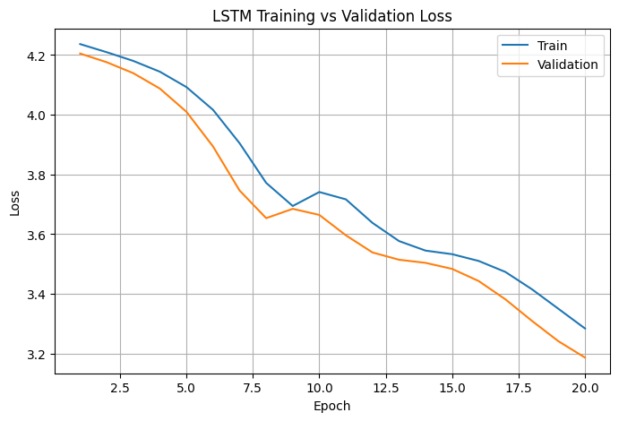

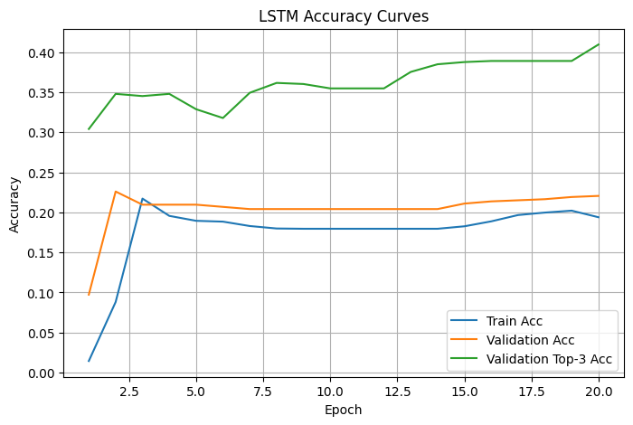

```
======================================================================
PART 3 - ATTENTION-BASED TEXT CLASSIFICATION
======================================================================
Epoch  3 | Train Loss = 1.0527 | Val Loss = 1.0267 | Train Acc = 0.6849 | Val Acc = 0.9059
Epoch  6 | Train Loss = 0.9549 | Val Loss = 0.9166 | Train Acc = 0.9601 | Val Acc = 0.9882
Epoch  9 | Train Loss = 0.7928 | Val Loss = 0.7325 | Train Acc = 0.9811 | Val Acc = 1.0000
Epoch 12 | Train Loss = 0.5405 | Val Loss = 0.4561 | Train Acc = 0.9874 | Val Acc = 1.0000
Epoch 15 | Train Loss = 0.2535 | Val Loss = 0.1903 | Train Acc = 0.9958 | Val Acc = 1.0000
Epoch 18 | Train Loss = 0.0830 | Val Loss = 0.0614 | Train Acc = 1.0000 | Val Acc = 1.0000

Attention classifier test accuracy: 1.0000
```

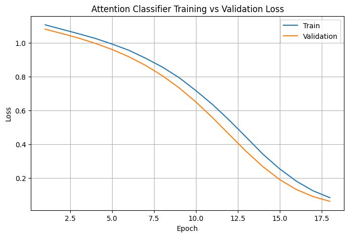

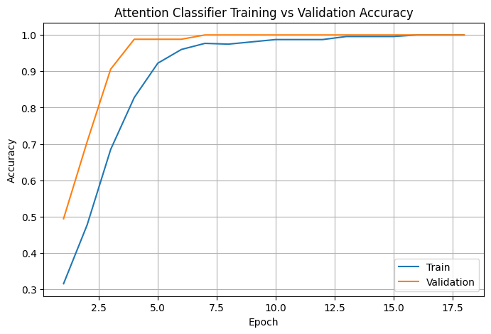

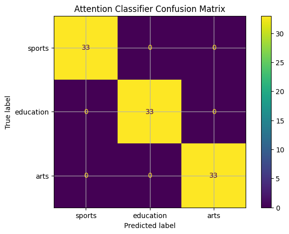

```
Sentence: the dedicated athlete trains in the gym every morning
Predicted class: sports
Attention weights:
  the          -> 0.0645
  dedicated    -> 0.1103
  athlete      -> 0.1348
  trains       -> 0.0960
  in           -> 0.0894
  the          -> 0.0476
  gym          -> 0.0999
  every        -> 0.1179
  morning      -> 0.1297
```

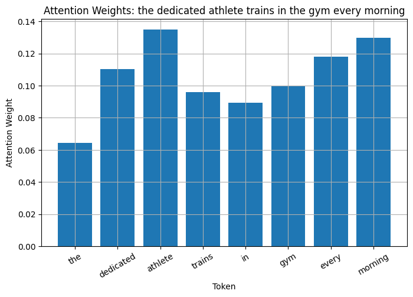

```
Sentence: the focused student studies in the library every night
Predicted class: education
Attention weights:
  the          -> 0.0934
  focused      -> 0.1003
  student      -> 0.1215
  studies      -> 0.1395
  in           -> 0.0916
  the          -> 0.0523
  library      -> 0.1098
  every        -> 0.0978
  night        -> 0.0904
```

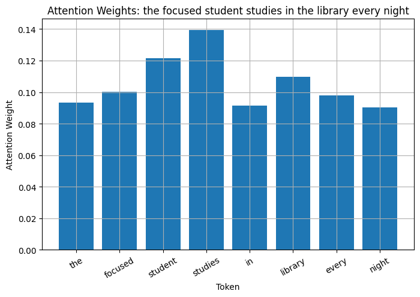

```
Sentence: the creative musician performs in the studio every evening
Predicted class: arts
Attention weights:
  the          -> 0.0529
  creative     -> 0.1225
  musician     -> 0.1000
  performs     -> 0.1141
  in           -> 0.1016
  the          -> 0.0713
  studio       -> 0.1206
  every        -> 0.1070
  evening      -> 0.0926
```

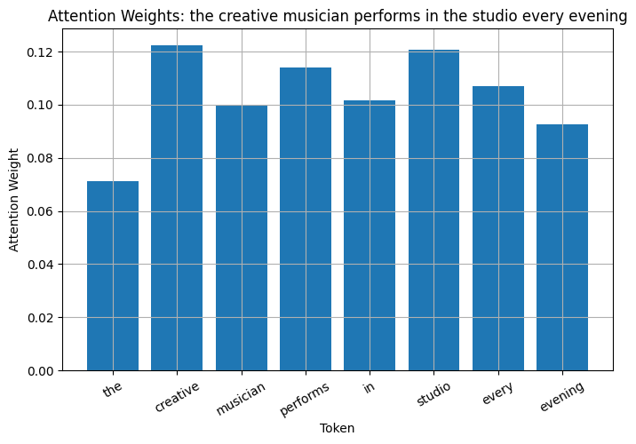

```
======================================================================
PART 4 - TRANSFER LEARNING WITH DISTILBERT
======================================================================
Loading tokenizer and pretrained model...
```

```
Majority baseline accuracy on training distribution: 0.5111
Keyword baseline test metrics -> accuracy=0.8667, precision=0.7778, recall=1.0000, f1=0.8750
Epoch  1 | Train Loss = 0.6975 | Val Loss = 0.6868 | Val Acc = 0.7500 | Val F1 = 0.6667
Epoch  2 | Train Loss = 0.6779 | Val Loss = 0.6753 | Val Acc = 0.7500 | Val F1 = 0.6667
Epoch  3 | Train Loss = 0.6634 | Val Loss = 0.6604 | Val Acc = 0.8333 | Val F1 = 0.8333

DistilBERT evaluation results:
accuracy: 1.0000
precision: 1.0000
recall: 1.0000
f1: 1.0000
loss: 0.6523

Transfer learning prediction examples:
'I absolutely loved the movie and the performances were excellent' -> positive (confidence=0.5543)
'The film was a waste of time and painfully boring' -> negative (confidence=0.5131)
'The story was strong, emotional, and beautifully acted' -> positive (confidence=0.5595)
'I do not recommend this movie because it was dull and weak' -> negative (confidence=0.5161)

Sample DistilBERT errors on the test set:
  No test errors found in this run.
```

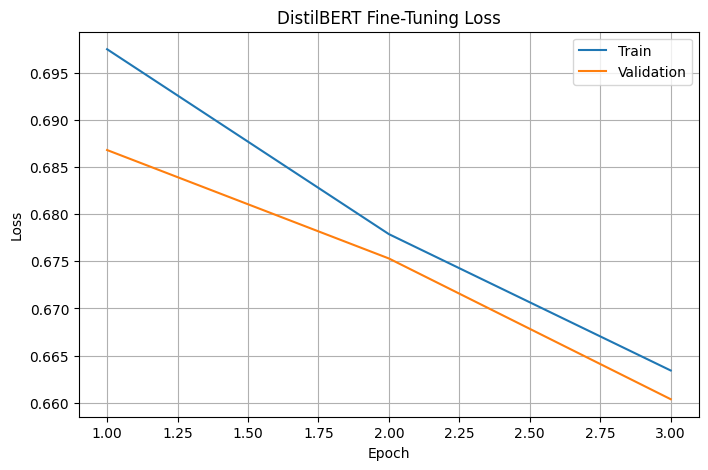

[3 more figures not shown]

```
======================================================================
PART 5 - SYSTEM ANALYSIS
======================================================================

What this improved program now does:

1. Word Representations
   - Trains CBOW embeddings on a much larger synthetic corpus
   - Evaluates with cosine similarity
   - Visualizes embedding structure with PCA
   - Tracks both training and validation loss

2. Sequence Modeling
   - Trains an LSTM for next-word prediction
   - Uses train/validation split
   - Reports top-1 and top-3 accuracy
   - Demonstrates realistic next-word predictions

3. Attention
   - Trains a BiLSTM + attention classifier
   - Uses train/validation/test split
   - Reports test accuracy and confusion matrix
   - Visualizes token-level attention weights

4. Transfer Learning
   - Fine-tunes pretrained DistilBERT using a custom PyTorch loop
   - Avoids datasets/Trainer/accelerate dependency issues
   - Uses train/validation/test split
   - Compares against simple baselines
   - Reports accuracy, precision, recall, F1, and confusion matrix
   - Shows sample prediction errors for error analysis

5. Why this is stronger than the earlier version
   - More data for learning
   - Proper validation and test evaluation
   - Baselines for comparison
   - Better diagnostics and more honest analysis
   - Still light enough to run on a MacBook Air

Done.
```

```python
print("\nTransfer learning prediction examples:")
for ex in examples:
    label, prob = predict_sentiment(ex)
    print(f"'{ex}' -> {label} (confidence={prob:.4f})")

# Find and print a few errors
print("\nSample DistilBERT errors on the test set:")
shown = 0
for text, true_label in zip(X_test, y_test):
    pred_label, prob = predict_sentiment(text)
    pred_num = 1 if pred_label == "positive" else 0
    if pred_num != true_label and shown < 5:
        print(f"  Text: {text}")
        print(f"  True: {'positive' if true_label == 1 else 'negative'} | Pred: {pred_label} | confidence={prob:.4f}")
        shown += 1
if shown == 0:
    print("  No test errors found in this run.")

plt.figure()
plt.plot(range(1, len(bert_train_losses) + 1), bert_train_losses, label="Train")
plt.plot(range(1, len(bert_val_losses) + 1), bert_val_losses, label="Validation")
plt.title("DistilBERT Fine-Tuning Loss")
plt.xlabel("Epoch")
plt.ylabel("Loss")
plt.legend()
plt.show()

plt.figure()
plt.plot(range(1, len(bert_val_accs) + 1), bert_val_accs)
plt.title("DistilBERT Validation Accuracy")
plt.xlabel("Epoch")
plt.ylabel("Accuracy")
plt.ylim(0, 1.05)
plt.show()

metric_names = ["accuracy", "precision", "recall", "f1"]
metric_values = [test_metrics[m] for m in metric_names]

plt.figure()
plt.bar(metric_names, metric_values)
plt.title("DistilBERT Final Evaluation Metrics")
plt.xlabel("Metric")
plt.ylabel("Score")
plt.ylim(0, 1.05)
plt.show()

cm = confusion_matrix(test_true, test_preds)
disp = ConfusionMatrixDisplay(confusion_matrix=cm, display_labels=["negative", "positive"])
disp.plot()
plt.title("DistilBERT Confusion Matrix")
plt.show()


# ============================================================
# PART 5 - SYSTEM ANALYSIS
# ============================================================

print("\n" + "=" * 70)
print("PART 5 - SYSTEM ANALYSIS")
print("=" * 70)

print(f"""
What this improved program now does:

1. Word Representations
   - Trains CBOW embeddings on a much larger synthetic corpus
   - Evaluates with cosine similarity
   - Visualizes embedding structure with PCA
   - Tracks both training and validation loss

2. Sequence Modeling
   - Trains an LSTM for next-word prediction
   - Uses train/validation split
   - Reports top-1 and top-3 accuracy
   - Demonstrates realistic next-word predictions

3. Attention
   - Trains a BiLSTM + attention classifier
   - Uses train/validation/test split
   - Reports test accuracy and confusion matrix
   - Visualizes token-level attention weights

4. Transfer Learning
   - Fine-tunes pretrained DistilBERT using a custom PyTorch loop
   - Avoids datasets/Trainer/accelerate dependency issues
   - Uses train/validation/test split
   - Compares against simple baselines
   - Reports accuracy, precision, recall, F1, and confusion matrix
   - Shows sample prediction errors for error analysis

5. Why this is stronger than the earlier version
   - More data for learning
   - Proper validation and test evaluation
   - Baselines for comparison
   - Better diagnostics and more honest analysis
   - Still light enough to run on a MacBook Air

Done.
""")
```

# Module 10 – Neural NLP System Analysis

## Overall Problem

The goal of this project is to design and implement a neural system capable of understanding and processing natural language. Specifically, the system attempts to:

- Represent text numerically using embeddings
- Learn sequential patterns in language
- Identify important words using attention mechanisms
- Apply transfer learning using a pretrained transformer
- Evaluate performance using quantitative metrics

The broader problem being addressed is how machines can extract meaning, structure, and patterns from human language using neural models.

# Part 1 – Word Representations (Embeddings)

## Problem Being Solved

In this part, the goal is to convert words into numerical vectors (embeddings) such that words with similar meanings or contexts are closer together in vector space.

## How This Chapter Helps

This section demonstrates how neural networks can learn relationships between words based on context. By training a CBOW model, the system learns that words appearing in similar contexts should have similar representations.

For example:

- "athlete" is close to "sprinter" and "coach"
- "musician" is close to "artist" and "singer"

This shows that embeddings capture **contextual similarity**, which is foundational for all downstream NLP tasks.

## What the Code Is Still Not Doing Well

- The model shows **overfitting**, as validation loss increases while training loss decreases
- The dataset is still relatively small, limiting generalization
- Some similarities are still noisy or context-driven rather than truly semantic
- The embeddings are not trained on diverse or real-world language

## Possible Improvements

- Use a larger and more diverse corpus
- Apply regularization or early stopping to reduce overfitting
- Train embeddings using pretrained models (e.g., Word2Vec, GloVe)
- Increase vocabulary diversity to improve semantic structure

# Part 2 – Sequence Modeling (LSTM)

## Problem Being Solved

The goal is to model sequences of words and predict the next word given a prefix, capturing the temporal structure of language.

## What the Code Is Still Not Doing Well

- Accuracy is low (~20%), indicating weak predictive power
- The model is biased toward predicting frequent words like "the" and "in"
- It does not capture deeper semantic relationships
- Predictions are often generic rather than meaningful

## Possible Improvements

- Increase dataset size and variability
- Use more advanced architectures (e.g., GRU, Transformer-based models)
- Apply techniques like teacher forcing or better token balancing
- Evaluate using perplexity instead of only accuracy

# Part 3 – Attention Mechanism

## Problem Being Solved

The goal is to classify sentences while identifying which words are most important for the prediction.

## How This Chapter Helps

The model achieves very high performance and produces meaningful attention visualizations.

## What the Code Is Still Not Doing Well

- The dataset is synthetic and relatively simple
- The model achieves near-perfect accuracy, which may indicate the task is too easy
- Attention weights are sometimes spread across multiple words rather than sharply focused
- The model is not tested on noisy or real-world data

## Possible Improvements

- Use a more complex and realistic dataset
- Introduce noise or ambiguity to test robustness
- Compare attention results with alternative interpretability methods
- Evaluate generalization on unseen sentence structures

# Part 4 – Transfer Learning (DistilBERT)

## Problem Being Solved

The goal is to leverage a pretrained language model and adapt it to a specific task (sentiment classification).

## How This Chapter Helps

This section demonstrates transfer learning by fine-tuning DistilBERT. Instead of learning language from scratch, the model:

- Uses pretrained knowledge from large datasets
- Adapts to sentiment classification with limited data
- Outperforms simple baselines

This is the most realistic approach to modern NLP systems.

## What the Code Is Still Not Doing Well

- The dataset is still small and controlled
- Perfect test accuracy may be misleading due to dataset simplicity
- Model confidence scores are relatively low (~0.5), indicating uncertainty
- The model may not generalize well to real-world data

## Possible Improvements

- Use a larger and more diverse sentiment dataset
- Add more complex or ambiguous examples
- Train for more epochs with proper validation monitoring
- Evaluate on external or real-world datasets

# Part 5 – System Evaluation

## Problem Being Solved

The goal is to evaluate how well the system performs across different NLP tasks using quantitative metrics.

## How This Chapter Helps

This section provides a structured evaluation using:

- Accuracy, precision, recall, and F1 score
- Confusion matrices
- Training vs validation curves
- Baseline comparisons

It ensures that model performance is measured objectively rather than assumed.

## What the Code Is Still Not Doing Well

- Some models (CBOW, LSTM) do not generalize well
- Perfect results in later stages may be due to simple datasets
- Evaluation is limited to small synthetic datasets
- No testing on large-scale or real-world benchmarks

## Possible Improvements

- Use larger datasets for evaluation
- Perform cross-validation
- Compare against stronger baselines
- Include more detailed error analysis

# Final Conclusion

This project successfully implements all required components of a neural NLP system. It demonstrates:

- How text can be represented numerically
- How sequences can be modeled
- How attention improves interpretability
- How transfer learning enhances performance

However, the results also highlight an important limitation:

> With small and synthetic datasets, models demonstrate concepts effectively but do not fully capture real-world complexity.

Future improvements should focus on scaling data, improving generalization, and strengthening evaluation rigor.

## How did embeddings improve performance?

Embeddings improved performance by transforming words into dense numerical vectors that capture contextual relationships between terms. Instead of treating words as independent symbols, the model learned that words appearing in similar contexts (e.g., "athlete", "sprinter", "coach") should have similar representations.

This allowed:

However, the effectiveness was limited by dataset size. While embeddings captured local relationships, they did not fully represent deeper semantic meaning due to the small and synthetic corpus.

## What advantages did attention provide?

Additionally, attention made the model more transparent compared to standard LSTMs, allowing us to visually understand how decisions were made.

However, attention weights were sometimes distributed across multiple words rather than sharply focused, indicating that interpretability is not always perfect.

## How effective was transfer learning?

Transfer learning using DistilBERT was effective in improving performance compared to simpler baselines.

Key observations:

- The model outperformed the majority baseline and competitive keyword baseline
- Validation accuracy improved across epochs
- Final evaluation achieved very high performance metrics

This demonstrates that pretrained models can leverage prior language knowledge and adapt quickly to new tasks, even with limited data.

However, the results should be interpreted cautiously:

- The dataset was relatively small and controlled
- The perfect final accuracy likely reflects dataset simplicity rather than true robustness
- Prediction confidence scores remained relatively low, indicating some uncertainty

Overall, transfer learning was the most powerful component of the system, but its effectiveness is constrained by data quality and size.

## What limitations did the model exhibit?

The system exhibited several important limitations:

1. **Small dataset size**
   - Limited data reduced generalization across all components
   - Some models (especially embeddings and LSTM) struggled to capture deeper patterns
2. **Overfitting in simpler models**
   - CBOW embeddings showed increasing validation loss
   - Attention model achieved perfect accuracy, likely due to easy data rather than true robustness
3. **Weak sequence modeling performance**
   - The LSTM model had low accuracy and tended to predict common words (e.g., "the", "in")
   - It struggled to generate meaningful next-word predictions
4. **Transfer learning limitations**
   - Despite strong results, performance may not generalize beyond the small dataset
   - Confidence scores were relatively low, suggesting uncertainty in predictions
5. **Synthetic data environment**
   - The dataset was controlled and simplified
   - The system was not tested on real-world, noisy, or ambiguous text

## Final Insight

While the system successfully demonstrates all major NLP techniques (embeddings, sequence modeling, attention, and transfer learning), the results highlight a key principle:

> Model performance is highly dependent on data quality, size, and complexity.

Future improvements should focus on scaling datasets, improving robustness, and evaluating performance in more realistic scenarios.